# Generación de números aleatorios con "dispositivos" físicos

## Baterías de pruebas estadísticas para números pseudoaleatorios uniformes

### Pruebas de bondad de bondad de ajuste

- Kolmogorov-Smirnoff.
- Pruebas $\chi^2$.
- Gráfico Q-Q.

#### Kolmogorov-Smirnoff

Sea $F$ una función cumulativa de distribución y $X_1, \ldots , X_n \stackrel{\text{i.i.d.}}{\sim}\mathcal{L}(F)$. Recordemos que la distribución empírica está dada por

\begin{align*} \hat{F}_n(x) = \frac{1}{n}\sum_{i=1}^n \mathbb{1}\left\{ X_i \leq x \right\} \end{align*}

El teorema de Glivenko-Cantelli nos dice que

\begin{align*} \sup_x |\hat{F}_n(x)-F(x)| \stackrel{\text{c.s.}}{\to} 0 \end{align*}

Así como para la "ley de los grandes números" el "teorema del límite central" da la tasa con la cual se convergen a una distribución, el teorema de Donsker nos dice

\begin{align*} \sqrt{n}(\hat{F}_n(x)-F(x)) \stackrel{\text{d}}{\to}B(x) \end{align*}

con $B(x)$ un cierto puente browniano.

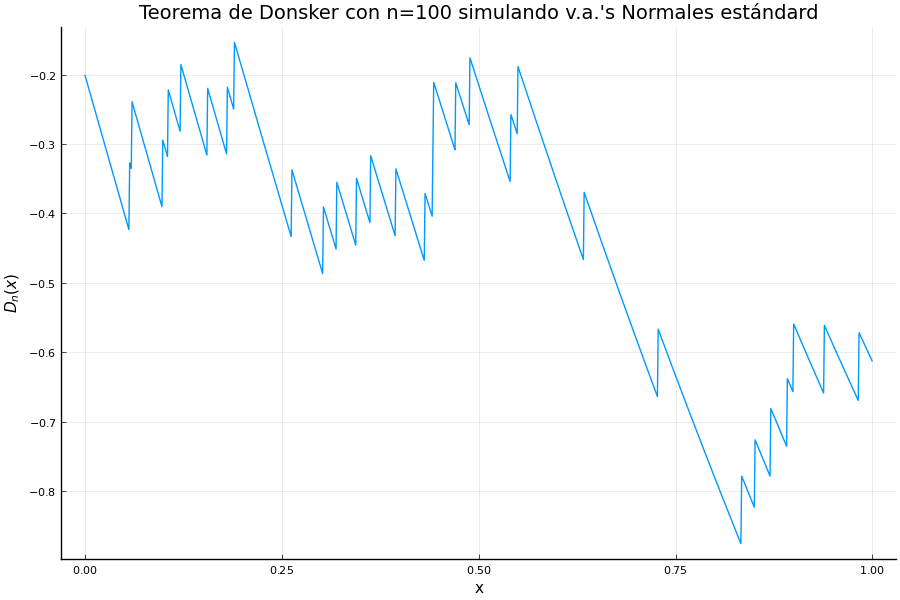

```julia
plot(p)
```

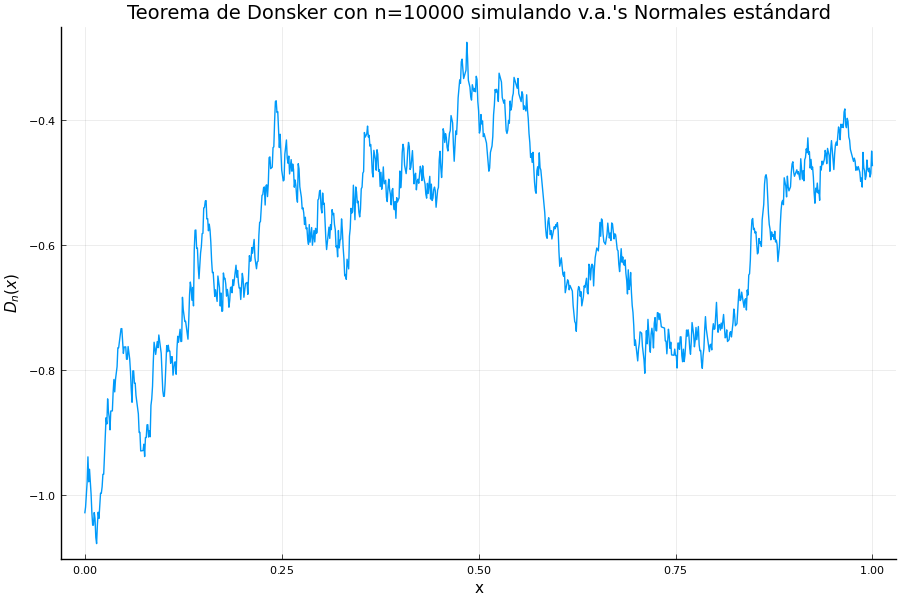

```julia
plot(p)
```

Esto motiva ultizar $\sup_x D_n(x)$ como un estadístico de prueba al que se le llama estadístico de Kolomogorov-Smirnoff y sirve para hacer pruebas de hipótesis sobre $H_0 \, : \,X_1, \ldots , X_n \stackrel{\text{i.i.d.}}{\sim}\mathcal{L}(F)$.

### Pruebas $\chi^2$

En las pruebas $\chi^2$ se utiliza el teorema de Pearson, el cual nos dice que

\begin{align*} \lim_{n\to \infty}\sum_{i=1}^n \frac{(O_i-E_i)^2}{E_i} \stackrel{d}{\to}\chi^2(n-p) \end{align*}

donde $O_i$ son observaciones de tipo $i$ / en la celda $i$, $E_i$ es le número esperado de observaciones de tipo $i$ / en la celda $i$ bajo la hipótesis nula de que la probabilidad de tal evento es $p_i$ y $p$ es el número de parámetros estimados en la distribución multinomial subyacente.

La prueba $\chi^2$ puede ser usada ṕara probar independencia o la prueba de bondad de ajuste $H_0 \, : \,X_1, \ldots , X_n \stackrel{\text{i.i.d.}}{\sim}\mathcal{L}(F)$.

### Gráficos Q-Q

Visualizamos los cuantiles teóricos contra los cuantiles muestrales.

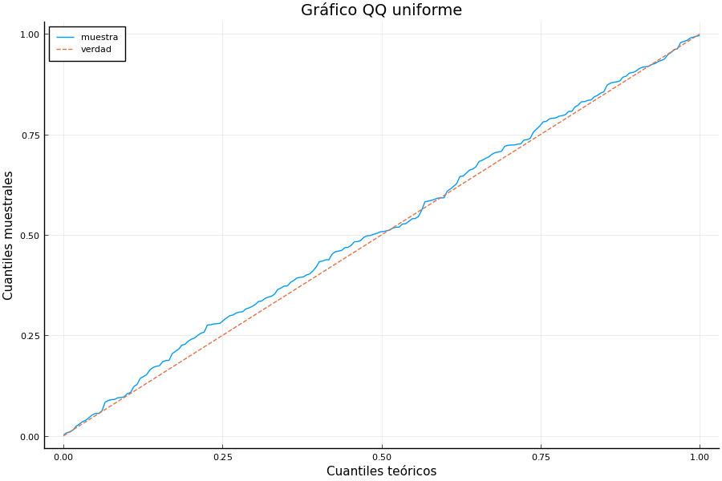

```julia
plot(p)
```

### Baterías de pruebas

- Die hard (1996)
- TestU01 (2007)
  - Small crush
  - Big crush
- Die harder (2007)